# Bitcoin: one macro cycle on a strong trend

## Step 3: trend out, then prefit the cycle

Remove a log-trend on the training window, then prefit one macro sine on the residual (phase locked to known peak years), including the exponential floor $(a,(1-a)e^{-\kappa t})$.

```
Train: 2010-08-18 to 2025-06-05 (n=5406)
Test:  2025-06-06 to 2026-06-05 (n=365)
```

```
omega=5.0  phase=0.103  time_scale=0.9061
trend prefit: B=6.0580  C=-41.2851  z=-735.9091  gamma=0.0000
envelope prefit: f=0.3990  a_floor=1.0000  kappa=0.0000
```

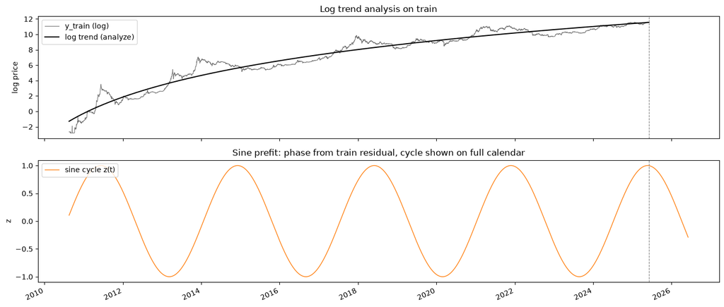

```python
t_idx = btc.day_index(n)
split = btc.split_holdout(n, n_test=TEST_DAYS, dates=dates, min_train=30)
train_idx, test_idx = split["train_idx"], split["test_idx"]
n_train = split["n_train"]
y_tr, y_te = y[train_idx], y[test_idx]
t_tr, t_te = t[train_idx], t[test_idx]
t_idx_tr = t_idx[train_idx]
dates_tr, dates_te = split["dates_train"], split["dates_test"]

print(f"Train: {dates_tr[0].date()} to {dates_tr[-1].date()} (n={n_train})")
print(f"Test:  {dates_te[0].date()} to {dates_te[-1].date()} (n={split['n_test']})")

prep = analyze_log_trend(y_tr, t_idx_tr)
peak_idx = btc.detect_btc_cycle_peaks(y_tr, dates_tr)
pf = prefit(
    prep.residual,
    t_tr,
    n_sines=1,
    peak_idx=peak_idx,
    omega=float(N_CYCLE_PEAKS),
    envelope_init=True,
    t_full=t,
)
trend_pre = prep.trend
sine_fit = pf.sine_fit
z_pre = sine_fit["z"]
z_full = sine_fit["z_full"]
sine_fit_full = {**sine_fit, "z": z_full[:n_train]}

print(f"omega={sine_fit['omega']:.1f}  phase={sine_fit['phase']:.3f}  time_scale={sine_fit['time_scale']:.4f}")
print(
    f"trend prefit: B={prep.B:.4f}  C={prep.C:.4f}  z={prep.z:.4f}  gamma={prep.gamma:.4f}"
)
print(
    f"envelope prefit: f={sine_fit.get('f_init', float('nan')):.4f}  "
    f"a_floor={sine_fit.get('a_floor_init', sine_fit.get('a_inf_init', float('nan'))):.4f}  "
    f"kappa={sine_fit.get('kappa_init', sine_fit.get('lam_init', float('nan'))):.4f}"
)

fig, axes = plt.subplots(2, 1, figsize=(14, 6), sharex=True)
ax0, ax1 = axes
ax0.plot(dates_tr, y_tr, color="0.45", lw=0.8, label="y_train (log)")
ax0.plot(dates_tr, trend_pre, color="black", lw=1.5, label="log trend (analyze)")
ax0.axvline(dates_tr[-1], color="gray", ls="--", lw=0.8)
ax0.set_ylabel("log price")
ax0.set_title("Log trend analysis on train")
ax0.legend(loc="upper left")
ax1.plot(dates, z_full, color="C1", lw=1.0, label="sine cycle z(t)")
ax1.axvline(dates_tr[-1], color="gray", ls="--", lw=0.8)
ax1.set_ylabel("z")
ax1.set_title("Sine prefit: phase from train residual, cycle shown on full calendar")
ax1.legend(loc="upper left")
btc.format_date_axis(ax1, dates)
fig.tight_layout()
plt.show()
```

## Step 4: fit warp + observation model

Jointly learn path knots and the MLP / envelope observation terms on train only, under $\lambda = 0.5$.

```
fit_lambda = 0.5
epochs          = 4000
path_anchor     = start
R² (train) = 0.9799
error NLL  = 3836.9  −terror = 0.5
sigma_y         = 0.5521
sigma_t         = 0.1708
sigma_index     = 4.7454
trend: B=4.8656  C=-30.7971  z=-285.4402  gamma=0.0000
envelope: a_floor=0.9999  kappa=0.0000
max offset      = 312.8 days
start-pin: p[0]=0.000  offset[0]=0.0000  terminal_offset=-152.0605
```

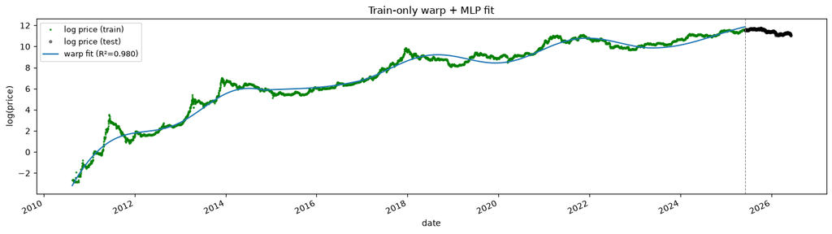

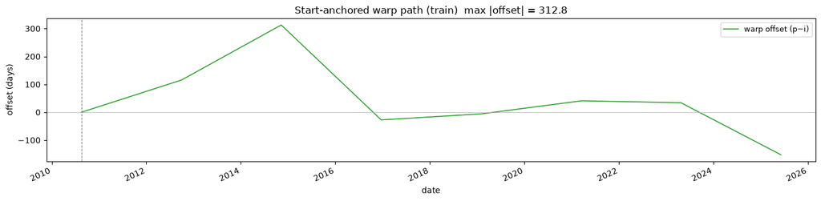

```python
from warp_regression import WarpModel, per_index_rw_sigma

model = WarpModel.from_yaml(
    "bitcoin.yaml",
    overrides={
        "train": {
            "epochs": EPOCHS,
            "lr": WARP_LR,
            "fit_lambda": FIT_LAMBDA,
            "seed": 0,
        },
        "n_knots": N_KNOTS,
    },
)
fit_res = model.fit(
    y_tr,
    covariates={"z": np.asarray(sine_fit_full["z"], dtype=np.float64)[:n_train]},
    calendar={"t_idx": t_idx_tr, "t_norm": t_tr},
    sine_fit=sine_fit_full,
)
fit = fit_res.fit
fit["y_hat"] = fit_res.y_hat
fit["r2"] = fit_res.r2
fit["sine_fit"] = sine_fit_full
fit["n_calendar"] = int(round(0.5 / float(t_tr[0]))) if len(t_tr) else n_train
fit["_y_test"] = y_te
fit["_model"] = model

y_hat = fit["y_hat"]
n_knots = fit["n_knots"]
p_tr = fit["warp"]["p"]
off_tr = stored_path_offset_numpy(p_tr)
print(f"fit_lambda = {FIT_LAMBDA}")
print(f"epochs          = {EPOCHS}")
assert fit["warp"]["path_anchor"] == "start"
assert abs(float(p_tr[0])) < 1e-5 and abs(float(off_tr[0])) < 1e-5
print(f"path_anchor     = {fit['warp']['path_anchor']}")
w = fit["warp"]
print(f"R² (train) = {fit['r2']:.4f}")
print(f"error NLL  = {w['obj_err']:.1f}  −terror = {w['obj_time']:.1f}")
print(f"sigma_y         = {fit['warp']['sigma_y']:.4f}")
print(f"sigma_t         = {fit['warp']['sigma_t']:.4f}")
print(f"sigma_index     = {per_index_rw_sigma(fit['warp']['sigma_t'], n_train, n_knots):.4f}")
ro = fit["observation"]
print(
    f"trend: B={float(ro.trend_B.detach()):.4f}  C={float(ro.trend_C.detach()):.4f}  z={float(ro.z_shift.detach()):.4f}  "
    f"gamma={float(ro.gamma.detach()):.4f}"
)
print(
    f"envelope: a_floor={float(ro.a_floor.detach()):.4f}  kappa={float(ro.kappa.detach()):.4f}"
)
print(f"max offset      = {fit['warp']['max_abs_offset']:.1f} days")
print(f"start-pin: p[0]={p_tr[0]:.3f}  offset[0]={off_tr[0]:.4f}  terminal_offset={off_tr[-1]:.4f}")

fig, ax = plt.subplots(figsize=(14, 4))
ax.plot(dates_tr, y_tr, "g.", ms=3, alpha=0.7, label="log price (train)")
ax.plot(dates_te, y_te, "ko", ms=3, alpha=0.45, label="log price (test)")
ax.plot(dates_tr, y_hat, color="C0", lw=1.5, label=f"warp fit (R²={fit['r2']:.3f})")
ax.axvline(split["train_end_date"], color="gray", ls="--", lw=0.8)
ax.set_title("Train-only warp + MLP fit")
ax.set_xlabel("date")
ax.set_ylabel("log(price)")
ax.legend(loc="upper left", fontsize=9)
btc.format_date_axis(ax, dates)
fig.tight_layout()
plt.show()

fig, ax = plt.subplots(figsize=(14, 3.5))
plot_warp_offset(
    ax, dates_tr, p_tr, anchor_x=dates_tr[0], color="C2",
    label="warp offset (p−i)",
    title=f"Start-anchored warp path (train)  max |offset| = {fit['warp']['max_abs_offset']:.1f}",
)
ax.set_ylabel("offset (days)")
ax.set_xlabel("date")
btc.format_date_axis(ax, dates)
fig.tight_layout()
plt.show()
```

## Step 5: holdout forecast

Sample start-pinned future paths, add a residual MA correction, and build terror / combined bands.

```
terminal_offset=-152.061  path_anchor=start  yhat_end=11.893 y_end=11.559
frozen σ_t=0.1708  σ_y=0.5521 (from fit)
residual MA: level=+0.0221  sigma=0.2373  horizon=365
Point forecast train/test corr = 0.991 / 0.001
CI nominal=95%  |  actual total=88.2%  |  actual warp=0.0%
```

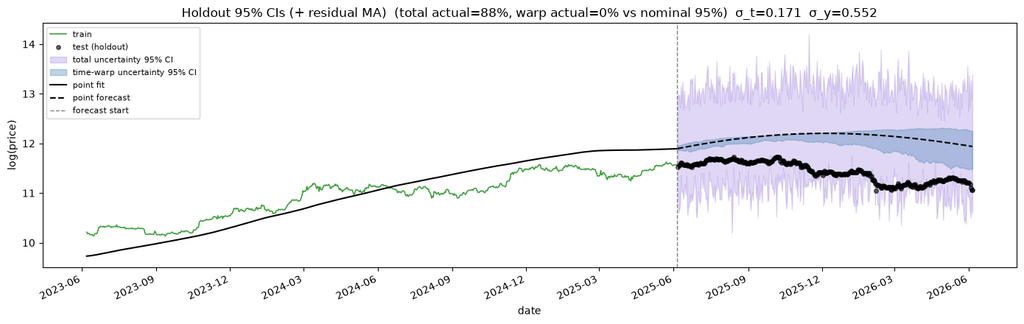

```python
from utils import plot_forecast_bands, plot_warp_offset
from warp_regression import (
    apply_residual_forecast,
    as_forecast_state,
    fit_residual_smooth,
    forecast_from_state,
)

ci = 0.95
n_show = N_SINGLE_PATHS
hist_start = max(0, n_train - int(2 * 365.25))

state = as_forecast_state(
    fit, t_idx_full=t_idx, t_norm_full=t, z_full=z_full, n_obs=n_train
)
assert state.path_anchor == "start"
fc = forecast_from_state(
    state, n_future=split["n_test"], n_draws=n_show, n_paths_ci=n_show,
    seed=43, noise_seed=44, ci=ci,
)

# Residual MA on train residuals, then fold into the forecast (point + bands).
res_fit = fit_residual_smooth(y_tr - fit["y_hat"], horizon=split["n_test"])
fc = apply_residual_forecast(fc, res_fit, n_train, fc["sigma_y"], noise_seed=44)
bands = fc["bands"]
y_point = fc["y_point"]

cov_total = interval_coverage(y_te, bands["c_q_lo"][test_idx], bands["c_q_hi"][test_idx])
cov_warp = interval_coverage(y_te, bands["t_q_lo"][test_idx], bands["t_q_hi"][test_idx])
ci_pct = int(round(100 * ci))

print(
    f"terminal_offset={fc.get('terminal_offset', float('nan')):.3f}  "
    f"path_anchor={state.path_anchor}  "
    f"yhat_end={y_point[n_train-1]:.3f} y_end={y_tr[-1]:.3f}"
)
print(f"frozen σ_t={fc['sigma_t']:.4f}  σ_y={fc['sigma_y']:.4f} (from fit)")
print(
    f"residual MA: level={res_fit.level:+.4f}  sigma={res_fit.sigma:.4f}  "
    f"horizon={res_fit.horizon}"
)
print(
    f"Point forecast train/test corr = "
    f"{np.corrcoef(y_point[:n_train], y_tr)[0, 1]:.3f} / "
    f"{np.corrcoef(y_point[test_idx], y_te)[0, 1]:.3f}"
)
print(
    f"CI nominal={ci:.0%}  |  actual total={cov_total:.1%}  |  actual warp={cov_warp:.1%}"
)

bands_test = {k: bands[k][test_idx] for k in ("t_q_lo", "t_q_hi", "c_q_lo", "c_q_hi")}
bands_test["ci"] = ci

fig, ax = plt.subplots(figsize=(14, 4.5))
plot_forecast_bands(
    ax,
    dates[hist_start:n_train],
    y[hist_start:n_train],
    dates_te,
    bands_test,
    x_test=dates_te,
    y_test=y_te,
    point_lines=[
        (dates[hist_start:n_train], y_point[hist_start:n_train], {"color": "black", "lw": 1.5, "label": "point fit"}),
        (dates_te, y_point[test_idx], {"color": "black", "lw": 1.5, "ls": "--", "label": "point forecast"}),
    ],
    forecast_start_x=split["train_end_date"],
    train_label="train",
    test_label="test (holdout)",
    ylabel="log(price)",
    xlabel="date",
    title=(
        f"Holdout {ci_pct}% CIs (+ residual MA)  "
        f"(total actual={cov_total:.0%}, warp actual={cov_warp:.0%} vs nominal {ci_pct}%)  "
        f"σ_t={fc['sigma_t']:.3f}  σ_y={fc['sigma_y']:.3f}"
    ),
)
btc.format_date_axis(ax, dates[hist_start:])
fig.tight_layout()
plt.show()
```

## Step 6: five-year forecast

Refit on the full series and push a five-year path sample with the same residual correction.

```
Full-series presize + warp fit for 5-year forecast
```

```
Full-series R²=0.9666  error NLL=3990.3  −terror=0.4  sigma_y = 0.5413  sigma_t = 0.1708
path_anchor=start  p[0]=0.000  terminal_offset=-4.266
terminal_offset=-4.266  yhat_end=11.648 y_end=11.064
frozen σ_t=0.1708  σ_y=0.5413 (from fit)
residual MA: level=-0.4525  sigma=0.3285  horizon=1826
Forecast horizon: 2026-06-05 to 2031-06-05  (1826 days)
Point forecast at +5yr (log) = 12.607  price ~ $298,789
```

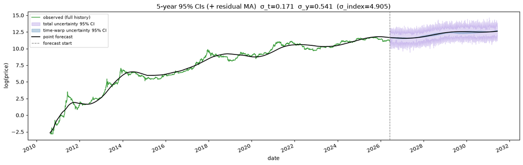

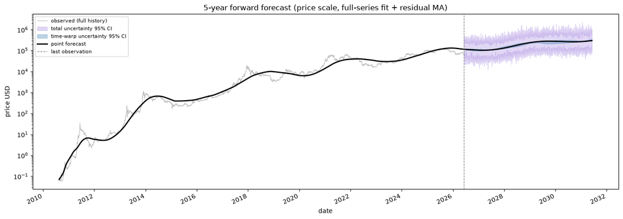

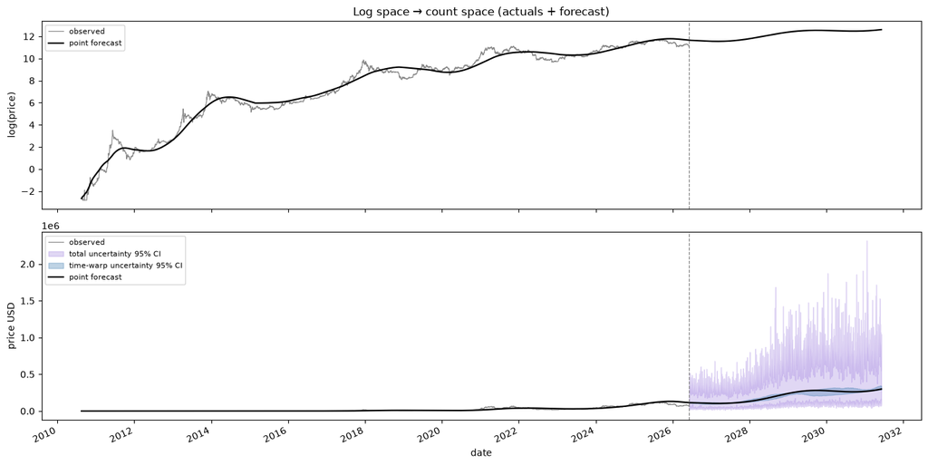

```python
print("Full-series presize + warp fit for 5-year forecast")
prep_all = analyze_log_trend(y, t_idx)
peak_all = btc.detect_btc_cycle_peaks(y, dates)
pf_all = prefit(
    prep_all.residual, t, n_sines=1, peak_idx=peak_all,
    omega=float(N_CYCLE_PEAKS), envelope_init=True, t_full=t,
)
sine_fit_all = pf_all.sine_fit
z_all = sine_fit_all["z_full"]
sine_fit_all_obs = {**sine_fit_all, "z": z_all}

model_full = WarpModel.from_yaml(
    "bitcoin.yaml",
    overrides={
        "train": {
            "epochs": EPOCHS,
            "lr": WARP_LR,
            "fit_lambda": FIT_LAMBDA,
            "seed": 0,
        },
        "n_knots": N_KNOTS,
    },
)
fit_full_res = model_full.fit(
    y,
    covariates={"z": np.asarray(sine_fit_all_obs["z"], dtype=np.float64)[:n]},
    calendar={"t_idx": t_idx, "t_norm": t},
    sine_fit=sine_fit_all_obs,
)
fit_full = fit_full_res.fit
fit_full["y_hat"] = fit_full_res.y_hat
fit_full["r2"] = fit_full_res.r2
fit_full["sine_fit"] = sine_fit_all_obs
fit_full["n_calendar"] = int(round(0.5 / float(t[0]))) if len(t) else n
fit_full["_model"] = model_full
n_knots_full = fit_full["n_knots"]
p_full = fit_full["warp"]["p"]
w_full = fit_full["warp"]
print(
    f"Full-series R²={fit_full['r2']:.4f}  "
    f"error NLL={w_full['obj_err']:.1f}  −terror={w_full['obj_time']:.1f}  "
    f"sigma_y = {fit_full['warp']['sigma_y']:.4f}  sigma_t = {fit_full['warp']['sigma_t']:.4f}"
)
print(
    f"path_anchor={fit_full['warp'].get('path_anchor', 'start')}  "
    f"p[0]={p_full[0]:.3f}  terminal_offset={stored_path_offset_numpy(p_full)[-1]:.3f}"
)

n_future_5 = FORECAST_5YR_DAYS
t_ext, t_idx_ext, z_ext, n_total_5 = btc.build_forecast_extension(n, n_future_5, sine_fit_all)
dates_ext = pd.date_range(dates[0], periods=n_total_5, freq="D")
dates_fut_5 = dates_ext[n:]

state5 = as_forecast_state(
    fit_full, t_idx_full=t_idx_ext, t_norm_full=t_ext, z_full=z_ext, n_obs=n
)
assert state5.path_anchor == "start"
fc5 = forecast_from_state(
    state5, n_future=n_future_5, n_draws=n_show, n_paths_ci=n_show,
    seed=101, noise_seed=102, ci=ci,
)
res_fit5 = fit_residual_smooth(y - fit_full["y_hat"], horizon=n_future_5)
fc5 = apply_residual_forecast(fc5, res_fit5, n, fc5["sigma_y"], noise_seed=102)
bands5 = fc5["bands"]
y_point5 = fc5["y_point"]

fut_sl = np.arange(n, n_total_5)
print(
    f"terminal_offset={fc5.get('terminal_offset', float('nan')):.3f}  "
    f"yhat_end={y_point5[n-1]:.3f} y_end={y[-1]:.3f}"
)
print(f"frozen σ_t={fc5['sigma_t']:.4f}  σ_y={fc5['sigma_y']:.4f} (from fit)")
print(
    f"residual MA: level={res_fit5.level:+.4f}  sigma={res_fit5.sigma:.4f}  "
    f"horizon={res_fit5.horizon}"
)
print(f"Forecast horizon: {dates[-1].date()} to {dates_fut_5[-1].date()}  ({n_future_5} days)")
print(f"Point forecast at +5yr (log) = {y_point5[-1]:.3f}  price ~ ${np.exp(y_point5[-1]):,.0f}")

bands5_fut = {k: bands5[k][fut_sl] for k in ("t_q_lo", "t_q_hi", "c_q_lo", "c_q_hi")}
bands5_fut["ci"] = ci
ci_pct = int(round(100 * ci))

# Full training history + forward CIs (log scale)
fig, ax = plt.subplots(figsize=(14, 4.5))
plot_forecast_bands(
    ax, dates, y, dates_fut_5, bands5_fut,
    point_lines=[
        (dates_ext, y_point5, {"color": "black", "lw": 1.5, "label": "point forecast"}),
    ],
    forecast_start_x=dates[-1],
    train_label="observed (full history)",
    xlabel="date", ylabel="log(price)",
    title=(
        f"5-year {ci_pct}% CIs (+ residual MA)  "
        f"σ_t={fc5['sigma_t']:.3f}  σ_y={fc5['sigma_y']:.3f}  "
        f"(σ_index={per_index_rw_sigma(fc5['sigma_t'], n, n_knots_full):.3f})"
    ),
)
btc.format_date_axis(ax, dates_ext)
fig.tight_layout()
plt.show()

# Full history on price scale
fig, ax = plt.subplots(figsize=(14, 5))
ax.semilogy(dates, price, color="0.75", lw=0.9, label="observed (full history)")
ax.fill_between(
    dates_fut_5, np.exp(bands5["c_q_lo"][fut_sl]), np.exp(bands5["c_q_hi"][fut_sl]),
    color="mediumpurple", alpha=0.28, label=f"total uncertainty {ci_pct}% CI",
)
ax.fill_between(
    dates_fut_5, np.exp(bands5["t_q_lo"][fut_sl]), np.exp(bands5["t_q_hi"][fut_sl]),
    color="steelblue", alpha=0.35, label=f"time-warp uncertainty {ci_pct}% CI",
)
ax.semilogy(dates_ext, np.exp(y_point5), "k", lw=2, label="point forecast")
ax.axvline(dates[-1], color="gray", ls="--", lw=0.9, label="last observation")
ax.set_ylabel("price USD")
ax.set_xlabel("date")
ax.set_title("5-year forward forecast (price scale, full-series fit + residual MA)")
ax.legend(fontsize=8, loc="upper left")
btc.format_date_axis(ax, dates_ext)
fig.tight_layout()
plt.show()

# Log space → count (price) space: actuals + point forecast (+ both CIs on count)
fig, axes = plt.subplots(2, 1, figsize=(14, 7), sharex=True)
axes[0].plot(dates, y, color="0.55", lw=0.9, label="observed")
axes[0].plot(dates_ext, y_point5, "k", lw=1.6, label="point forecast")
axes[0].axvline(dates[-1], color="gray", ls="--", lw=0.9)
axes[0].set_ylabel("log(price)")
axes[0].set_title("Log space → count space (actuals + forecast)")
axes[0].legend(fontsize=8, loc="upper left")

axes[1].plot(dates, price, color="0.55", lw=0.9, label="observed")
axes[1].fill_between(
    dates_fut_5, np.exp(bands5["c_q_lo"][fut_sl]), np.exp(bands5["c_q_hi"][fut_sl]),
    color="mediumpurple", alpha=0.28, label=f"total uncertainty {ci_pct}% CI",
)
axes[1].fill_between(
    dates_fut_5, np.exp(bands5["t_q_lo"][fut_sl]), np.exp(bands5["t_q_hi"][fut_sl]),
    color="steelblue", alpha=0.35, label=f"time-warp uncertainty {ci_pct}% CI",
)
axes[1].plot(dates_ext, np.exp(y_point5), "k", lw=1.6, label="point forecast")
axes[1].axvline(dates[-1], color="gray", ls="--", lw=0.9)
axes[1].set_ylabel("price USD")
axes[1].set_xlabel("date")
axes[1].legend(fontsize=8, loc="upper left")
btc.format_date_axis(axes[1], dates_ext)
fig.tight_layout()
plt.show()
```

## Step 7: next cycle length

Continue paths and measure spacing to the next peak of the warped macro sine. The dashed line is the nominal period $n/\omega$.

```
Nominal cycle ≈ 1308 days  |  sample median = 1281 days  |  σ_t = 0.171
```

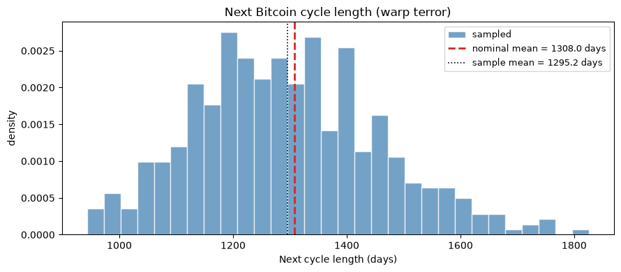

```python
from warp_regression import analyze_cycle_lengths, plot_cycle_length_distribution

cyc = analyze_cycle_lengths(
    fit=fit_full,
    sine_fit=sine_fit_all,
    n_calendar=n,
    unit="days",
    n_paths=500,
    seed=7,
)
fig, ax = plt.subplots(figsize=(9, 4))
plot_cycle_length_distribution(cyc, ax=ax, title="Next Bitcoin cycle length (warp terror)")
print(
    f"Nominal cycle ≈ {cyc.mean_cycle_length:.0f} days  |  "
    f"sample median = {np.median(cyc.lengths):.0f} days  |  "
    f"σ_t = {cyc.sigma_t:.3f}"
)
fig.tight_layout()
plt.show()
```

## Wrapping up

Same core idea across three notebooks: a known-shape cycle, a path with its own likelihood, and forecast / cycle-length uncertainty from sampling that path forward — here on a trending daily series with one dominant macro cycle.